# Foundations of Data Science Project - Diabetes Analysis

## Context

Diabetes is one of the most frequent diseases worldwide and the number of diabetic patients are growing over the years. The main cause of diabetes remains unknown, yet scientists believe that both genetic factors and environmental lifestyle play a major role in diabetes.

A few years ago research was done on a tribe in America which is called the Pima tribe (also known as the Pima Indians). In this tribe, it was found that the ladies are prone to diabetes very early. Several constraints were placed on the selection of these instances from a larger database. In particular, all patients were females at least 21 years old of Pima Indian heritage.

## Objective

Here, we are analyzing different aspects of Diabetes in the Pima Indians tribe by doing Exploratory Data Analysis.

## Data Dictionary

The dataset has the following information:

- Pregnancies: Number of times pregnant
- Glucose: Plasma glucose concentration over 2 hours in an oral glucose tolerance test
- BloodPressure: Diastolic blood pressure (mm Hg)
- SkinThickness: Triceps skin fold thickness (mm)
- Insulin: 2-Hour serum insulin (mu U/ml)
- BMI: Body mass index (weight in kg/(height in m)^2)
- DiabetesPedigreeFunction: A function that scores the likelihood of diabetes based on family history.
- Age: Age in years
- Outcome: Class variable (0: a person is not diabetic or 1: a person is diabetic)

## Q 1: Import the necessary libraries and briefly explain the use of each library (3 Marks)

```python
# Remove _____ & write the appropriate library name

import numpy as np

import pandas as pd

import seaborn as sns

import matplotlib.pyplot as plt

%matplotlib inline
```

#### Write your Answer here:

Ans 1: numby : to numerical arrays and calculations in python pandas :to analysis and manipulation data in python seaborn : to visualizations data in python matplotlub.pyplot : tool to creating a various types of charts in python

## Q 2: Read the given dataset (2 Marks)

```python
# Remove _____ & write the appropriate function name

pima = pd.read_csv("diabetes.csv")
pima.head()
```

|  | Pregnancies | Glucose | BloodPressure | SkinThickness | Insulin | BMI | DiabetesPedigreeFunction | Age | Outcome |
| --- | --- | --- | --- | --- | --- | --- | --- | --- | --- |
| 0 | 6 | 148 | 72 | 35 | 79 | 33.6 | 0.627 | 50 | 1 |
| 1 | 1 | 85 | 66 | 29 | 79 | 26.6 | 0.351 | 31 | 0 |
| 2 | 8 | 183 | 64 | 20 | 79 | 23.3 | 0.672 | 32 | 1 |
| 3 | 1 | 89 | 66 | 23 | 94 | 28.1 | 0.167 | 21 | 0 |
| 4 | 0 | 137 | 40 | 35 | 168 | 43.1 | 2.288 | 33 | 1 |

## Q3. Show the last 10 records of the dataset. How many columns are there? (2 Marks)

```python
# Remove ______ and write the appropriate number in the function

pima.tail(10)
```

|  | Pregnancies | Glucose | BloodPressure | SkinThickness | Insulin | BMI | DiabetesPedigreeFunction | Age | Outcome |
| --- | --- | --- | --- | --- | --- | --- | --- | --- | --- |
| 758 | 1 | 106 | 76 | 20 | 79 | 37.5 | 0.197 | 26 | 0 |
| 759 | 6 | 190 | 92 | 20 | 79 | 35.5 | 0.278 | 66 | 1 |
| 760 | 2 | 88 | 58 | 26 | 16 | 28.4 | 0.766 | 22 | 0 |
| 761 | 9 | 170 | 74 | 31 | 79 | 44.0 | 0.403 | 43 | 1 |
| 762 | 9 | 89 | 62 | 20 | 79 | 22.5 | 0.142 | 33 | 0 |
| 763 | 10 | 101 | 76 | 48 | 180 | 32.9 | 0.171 | 63 | 0 |
| 764 | 2 | 122 | 70 | 27 | 79 | 36.8 | 0.340 | 27 | 0 |
| 765 | 5 | 121 | 72 | 23 | 112 | 26.2 | 0.245 | 30 | 0 |
| 766 | 1 | 126 | 60 | 20 | 79 | 30.1 | 0.349 | 47 | 1 |
| 767 | 1 | 93 | 70 | 31 | 79 | 30.4 | 0.315 | 23 | 0 |

#### Write your Answer here:

Ans 3: 9 columns

## Q4. Show the first 10 records of the dataset (2 Marks)

```python
# Remove _____ & write the appropriate function name and the number of rows to get in the output

pima.head(10)
```

|  | Pregnancies | Glucose | BloodPressure | SkinThickness | Insulin | BMI | DiabetesPedigreeFunction | Age | Outcome |
| --- | --- | --- | --- | --- | --- | --- | --- | --- | --- |
| 0 | 6 | 148 | 72 | 35 | 79 | 33.600000 | 0.627 | 50 | 1 |
| 1 | 1 | 85 | 66 | 29 | 79 | 26.600000 | 0.351 | 31 | 0 |
| 2 | 8 | 183 | 64 | 20 | 79 | 23.300000 | 0.672 | 32 | 1 |
| 3 | 1 | 89 | 66 | 23 | 94 | 28.100000 | 0.167 | 21 | 0 |
| 4 | 0 | 137 | 40 | 35 | 168 | 43.100000 | 2.288 | 33 | 1 |
| 5 | 5 | 116 | 74 | 20 | 79 | 25.600000 | 0.201 | 30 | 0 |
| 6 | 3 | 78 | 50 | 32 | 88 | 31.000000 | 0.248 | 26 | 1 |
| 7 | 10 | 115 | 69 | 20 | 79 | 35.300000 | 0.134 | 29 | 0 |
| 8 | 2 | 197 | 70 | 45 | 543 | 30.500000 | 0.158 | 53 | 1 |
| 9 | 8 | 125 | 96 | 20 | 79 | 31.992578 | 0.232 | 54 | 1 |

## Q5. What do you understand by the dimension of the dataset? Find the dimension of the `pima` dataframe. (3 Marks)

```python
# Remove _____ & write the appropriate function name

pima.shape
```

```
(768, 9)
```

#### Write your Answer here:

Ans 5: see how many rows and columns

## Q6. What do you understand by the size of the dataset? Find the size of the `pima` dataframe. (3 Marks)

```python
# Remove _____ & write the appropriate function name

pima.size
```

```
6912
```

#### Write your Answer here:

Ans 6: the size of dataframe

## Q7. What are the data types of all the variables in the data set? (2 Marks)

**Hint: Use the info() function to get all the information about the dataset.**

```python
# Remove _____ & write the appropriate function name

pima.dtypes
```

```
Pregnancies                   int64
Glucose                       int64
BloodPressure                 int64
SkinThickness                 int64
Insulin                       int64
BMI                         float64
DiabetesPedigreeFunction    float64
Age                           int64
Outcome                       int64
dtype: object
```

#### Write your Answer here:

Ans 7: list each columns along with its data type

## Q8. What do we mean by missing values? Are there any missing values in the `pima` dataframe? (4 Marks)

```python
# Remove _____ & write the appropriate function name

pima.isnull().values.any()
```

```
False
```

#### Write your Answer here:

Ans 8: to check in the dataframe have any missing values if false its mean there is no missing values in dataframe

```python
# Remove _____ & write the appropriate function name

pima.iloc[: , 0 : 8].value_counts()
```

```
Pregnancies  Glucose  BloodPressure  SkinThickness  Insulin  BMI        DiabetesPedigreeFunction  Age
0            57       60             20             79       21.700000  0.735                     67     1
             67       76             20             79       45.300000  0.194                     46     1
5            104      74             20             79       28.800000  0.153                     48     1
             105      72             29             325      36.900000  0.159                     28     1
             106      82             30             79       39.500000  0.286                     38     1
                                                                                                        ..
2            84       69             20             79       31.992578  0.304                     21     1
             85       65             20             79       39.600000  0.930                     27     1
             87       58             16             52       32.700000  0.166                     25     1
                      69             23             79       28.900000  0.773                     25     1
17           163      72             41             114      40.900000  0.817                     47     1
Name: count, Length: 768, dtype: int64
```

## Q 10. Plot the distribution plot for the variable 'BloodPressure'. Write detailed observations from the plot. (2 Marks)

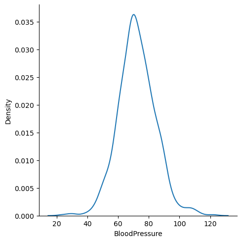

```python
# Remove _____ & write the appropriate library name

sns.displot(pima['BloodPressure'], kind = 'kde')

plt.show()
```

#### Write your Answer here:

Ans 10: base on the chart , we can see the index of density and BloodPressure and the highest index of Density is more than 0.035 with about 70 of BloodPressure

## Q 11. What is the 'BMI' of the person having the highest 'Glucose'? (2 Marks)

```python
# Remove _____ & write the appropriate function name

pima[pima['Glucose'] == pima['Glucose'].max()]['BMI']
```

```
661    42.9
Name: BMI, dtype: float64
```

## Q12.

### 12.1 What is the mean of the variable 'BMI'?

### 12.2 What is the median of the variable 'BMI'?

### 12.3 What is the mode of the variable 'BMI'?

### 12.4 Are the three measures of central tendency equal?

### (4 Marks)

```python
# Remove _____ & write the appropriate function name

m1 = pima['BMI'].mean()  # mean
print(m1)

m2 = pima['BMI'].median()  # median
print(m2)

m3 = pima['BMI'].mode()[0]  # mode
print(m3)
```

```
32.45080515543619
32.0
32.0
```

#### Write your Answer here:

Ans 12: three measures of central tendency is not equal

## Q13. How many women's 'Glucose' levels are above the mean level of 'Glucose'? (2 Marks)

```python
# Remove _____ & write the appropriate function name

pima[pima['Glucose'] > pima['Glucose'].mean()].shape[0]
```

```
343
```

#### Write your Answer here:

Ans 13: there are 343 women's have Glucose levels are higher than the mean level of 'Glucose'

## Q14. How many women have their 'BloodPressure' equal to the median of 'BloodPressure' and their 'BMI' less than the median of 'BMI'? (2 Marks)

```python
# Remove _____ & write the appropriate column name

pima[(pima['BloodPressure'] == pima['BloodPressure'].median()) & (pima['BMI'] < pima['BMI'].median())].shape[0]
```

```
22
```

#### Write your Answer here:

Ans 14:there are 22 women have their 'BloodPressure'equal to the median of 'BloodPressure'and their 'BMI'less than the median of 'BMI' and .shape is the function to counting the quantity .

## Q15. Create a pairplot for the variables 'Glucose', 'SkinThickness', and 'DiabetesPedigreeFunction'. Write your observations from the plot. (3 Marks)

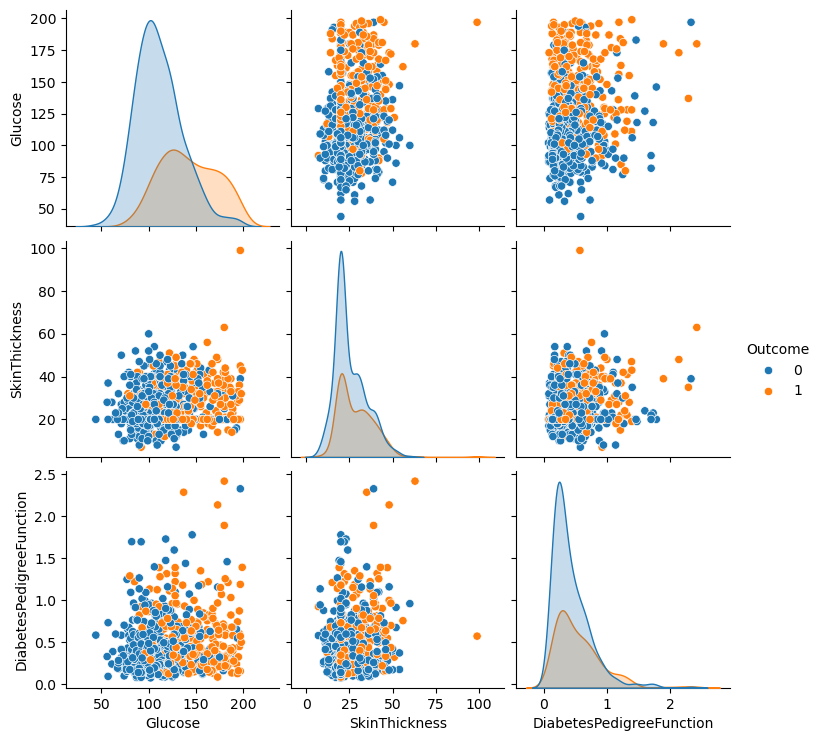

```python
# Remove _____ & write the appropriate function name

sns.pairplot(data = pima, vars = ['Glucose', 'SkinThickness', 'DiabetesPedigreeFunction'], hue = 'Outcome')
plt.show()
```

#### Write your Answer here:

Ans 15:Diabetics have higher glucose levels, according to the glucose vs. skin thickness plot. A weak correlation between elevated glucose and DiabetesPedigreeFunction is indicated by the glucose vs. diabetesPedigreeFunction comparison. Although there is no discernible correlation between SkinThickness and DiabetesPedigreeFunction, diabetics typically have higher values. Diabetics and non-diabetics can be distinguished by their blood glucose levels. DiabetesPedigreeFunction is right-skewed, particularly for non-diabetics, whereas SkinThickness is normal with a higher mean for diabetics, according to histograms and KDE plots.

## Q16. Plot the scatterplot between 'Glucose' and 'Insulin'. Write your observations from the plot. (4 Marks)

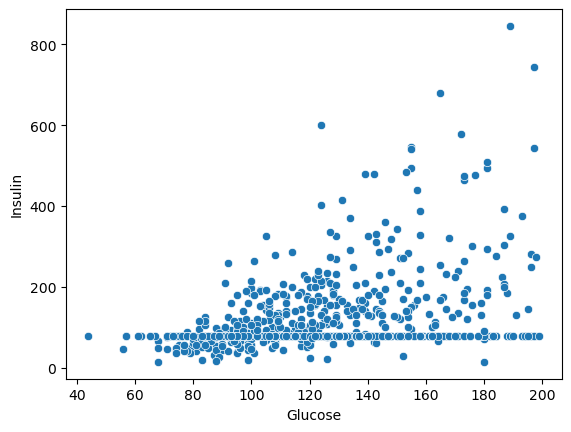

```python
# Remove _____ & write the appropriate function name

sns.scatterplot(x = 'Glucose', y = 'Insulin', data = pima)
plt.show()
```

#### Write your Answer here:

Ans 16:This scatterplot can be used to identify patterns or outliers that may indicate varying degrees of glucose tolerance, as well as to assess the relationship between glucose and insulin. Higher glucose levels are typically linked to higher insulin levels, according to the scatterplot between glucose and insulin, which demonstrates a positive correlation. The data points, however, are dispersed, especially at higher glucose levels, suggesting that insulin response varies. Along with a cluster of points at low insulin levels, there are also noticeable outliers with extremely high insulin levels, which could indicate missing or inaccurately recorded data.

## Q 17. Plot the boxplot for the 'Age' variable. Are there outliers? (2 Marks)

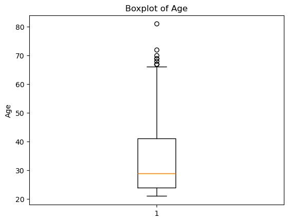

```python
# Remove _____ & write the appropriate function and column name

plt.boxplot(pima['Age'])

plt.title('Boxplot of Age')
plt.ylabel('Age')
plt.show()
```

#### Write your Answer here:

Ans 17:yes , there are outliners in the 'Age' variable .

## Q18. Plot histograms for the 'Age' variable to understand the number of women in different age groups given whether they have diabetes or not. Explain both histograms and compare them. (5 Marks)

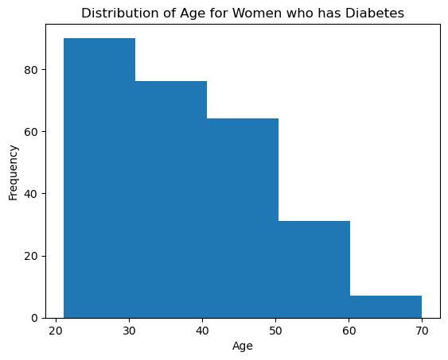

```python
# Remove _____ & write the appropriate function and column name

plt.hist(pima[pima['Outcome'] == 1]['Age'], bins = 5)
plt.title('Distribution of Age for Women who has Diabetes')
plt.xlabel('Age')
plt.ylabel('Frequency')
plt.show()
```

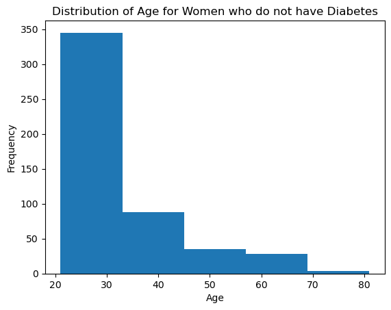

```python
# Remove _____ & write the appropriate function and column name

plt.hist(pima[pima['Outcome'] == 0]['Age'], bins = 5)
plt.title('Distribution of Age for Women who do not have Diabetes')
plt.xlabel('Age')
plt.ylabel('Frequency')
plt.show()
```

## Q 19. What is the Interquartile Range of all the variables? Why is this used? Which plot visualizes the same? (5 Marks)

```python
# Remove _____ & write the appropriate variable name

Q1 = pima.quantile(0.25)
Q3 = pima.quantile(0.75)
IQR = Q3 - Q1
print(IQR)
```

```
Pregnancies                  5.0000
Glucose                     40.5000
BloodPressure               16.0000
SkinThickness               12.0000
Insulin                     48.2500
BMI                          9.1000
DiabetesPedigreeFunction     0.3825
Age                         17.0000
Outcome                      1.0000
dtype: float64
```

#### Write your Answer here:

Ans 19:Compared to the range, the IQR is less impacted by outliers and aids in determining the distribution of the middle 50% of the data. The IQR is displayed using a boxplot, in which the whiskers extend to 1 point 5 times the IQR beyond Q1 and Q3, and the box represents the range between the first and third quartiles (Q1 to Q3). Outliers are data points that fall outside of the whiskers.

## Q 20. Find and visualize the correlation matrix. Write your observations from the plot. (3 Marks)

```python
# Remove _____ & write the appropriate function name and run the code

corr_matrix = pima.iloc[ : ,0 : 8].corr()

corr_matrix
```

|  | Pregnancies | Glucose | BloodPressure | SkinThickness | Insulin | BMI | DiabetesPedigreeFunction | Age |
| --- | --- | --- | --- | --- | --- | --- | --- | --- |
| Pregnancies | 1.000000 | 0.128022 | 0.208987 | 0.009393 | -0.018780 | 0.021546 | -0.033523 | 0.544341 |
| Glucose | 0.128022 | 1.000000 | 0.219765 | 0.158060 | 0.396137 | 0.231464 | 0.137158 | 0.266673 |
| BloodPressure | 0.208987 | 0.219765 | 1.000000 | 0.130403 | 0.010492 | 0.281222 | 0.000471 | 0.326791 |
| SkinThickness | 0.009393 | 0.158060 | 0.130403 | 1.000000 | 0.245410 | 0.532552 | 0.157196 | 0.020582 |
| Insulin | -0.018780 | 0.396137 | 0.010492 | 0.245410 | 1.000000 | 0.189919 | 0.158243 | 0.037676 |
| BMI | 0.021546 | 0.231464 | 0.281222 | 0.532552 | 0.189919 | 1.000000 | 0.153508 | 0.025748 |
| DiabetesPedigreeFunction | -0.033523 | 0.137158 | 0.000471 | 0.157196 | 0.158243 | 0.153508 | 1.000000 | 0.033561 |
| Age | 0.544341 | 0.266673 | 0.326791 | 0.020582 | 0.037676 | 0.025748 | 0.033561 | 1.000000 |

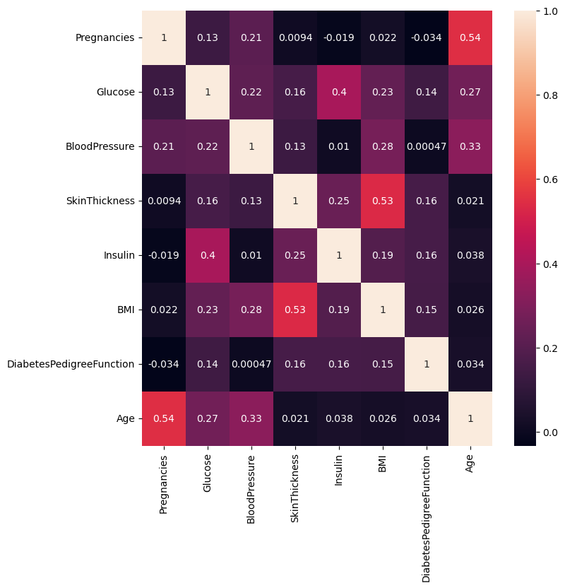

```python
# Remove _____ & write the appropriate function name

plt.figure(figsize = (8, 8))
sns.heatmap(corr_matrix, annot = True)

# Display the plot
plt.show()
```

#### Write your Answer here:

Ans 20:Given that older people typically have more pregnancies, there is a strong positive correlation between age and pregnancies (0.54). Additionally, there is a moderately positive correlation between skin thickness and BMI (0.53). Insulin resistance in diabetics is suggested by the moderate correlation between glucose and insulin (0point 40). Blood pressure and BMI (0.28) and glucose and age (0.27) have other moderate correlations. DiabetesPedigreeFunction is a distinct risk factor for diabetes, as evidenced by the weak correlations it exhibits with the majority of other variables. Minimal inverse relationships are indicated by a few weak negative correlations, such as the one between DiabetesPedigreeFunction (-0.03) and Pregnancies.